# Nimble Gp Comparing Priors

```r
library("gpmanagement")
library("tidyr")
library("dplyr")
```

```r
library("ggplot2")
```

Programming around nimble: Can we break out a piece of the nimble model definition to be diefined by users, using the nimble format (e.g. the priors), while leaving some of the model to be specified seperately?

At the moment this requires some trickery: https://stackoverflow.com/questions/31712646

It’s interesting to observe just how much nimble’s use (and extension!) of the powerful modeling expressions from BUGS has in common with the non-standard evaluation of Hadley’s `dplyr` and friends. With this in place in `gpmanagement` we can specify the prior externally.

First, some sample data

```r
# Should move my 'standard' sample data into the package?
  set.seed(1234)
  Tobs <- 40
  f <- function (x, h, p){
    sapply(x, function(x) {
        x <- pmax(0, x - h)
        x * exp(p[1] * (1 - x/p[2]) * (x - p[3])/p[2])
    })
  }
  p <- c(2, 100, 50)
  sigma_g <- 0.1
  z_g <- function() rlnorm(1, 0, sigma_g)
  x <- numeric(Tobs)
  x[1] <- 60
  for(t in 1:(Tobs-1))
    x[t+1] = z_g() * f(x[t], h=0, p=p)
  obs <- data.frame(x = c(0,
                          pmax(rep(0,Tobs-1), x[1:(Tobs-1)])),
                    y = c(0,
                          x[2:Tobs]))
  xObs <- obs$x
  yObs <- obs$y
  xPred <- seq(0, 1.25 * max(xObs), length = 50)
```

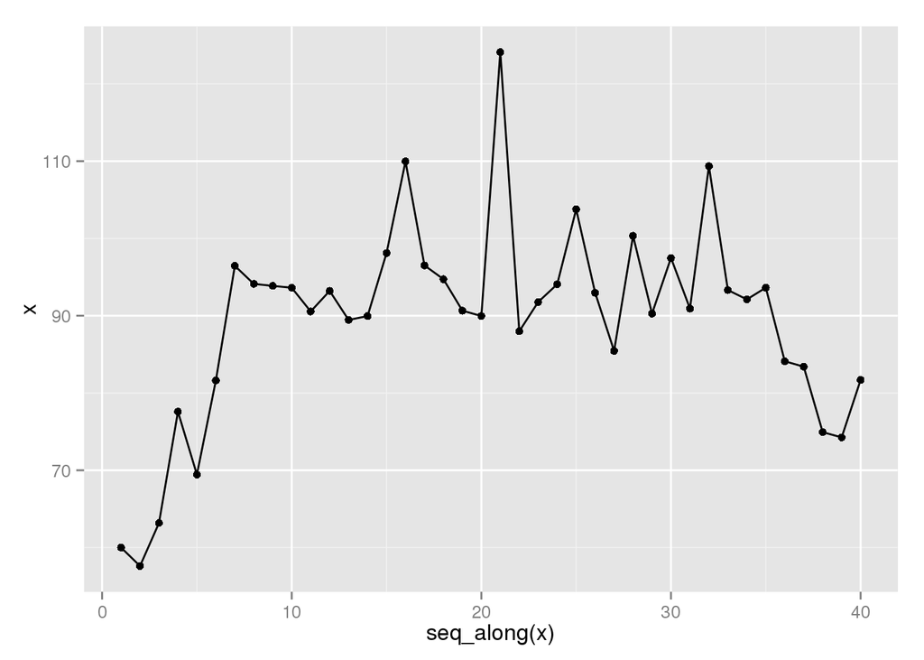

```r
qplot(seq_along(x), x) + geom_line()
```

Now the GP estimation from NIMBLE. Let’s emphasize shorter length-scales with the prior to compare:

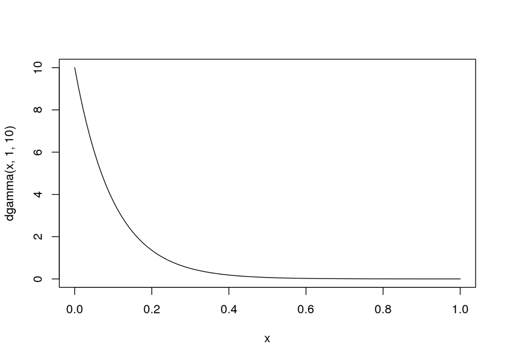

```r
# having this work with output from `nimbleCode` might be more natural than `expression`
priors <- expression({
  rho ~ dgamma(1, 10)
  sigGP ~ dunif(0, 1e5)
  sigOE ~ dunif(0, 1e5)
})
curve(dgamma(x, 1, 10))
```

```r
fit <- gp_setup(xObs[2:Tobs], yObs[2:Tobs], xPred)
```

```
## [1] RW_block sampler: rho, sigGP, sigOE,  adaptive: TRUE,  adaptScaleOnly: FALSE,  adaptInterval: 200,  scale: 1,  propCov: identity
```

```r
Cmcmc <- fit$Cmcmc
Cpred <- fit$Cpred
Cmodel <- fit$Cmodel
```

```r
system.time(Cmcmc$run(100000))
```

```
##    user  system elapsed
##  16.932   0.012  16.932
```

```r
  samples <- as.matrix(Cmcmc$mvSamples)
  ## basic sanity check
  testthat::expect_identical(Cmodel$getNodeNames(topOnly = TRUE), colnames(samples))
```

predict from GP model using posterior MCMC samples

```r
system.time(Cpred$run(samples))
```

```
##    user  system elapsed
##  22.276   0.000  22.259
```

extract predictions: E and C

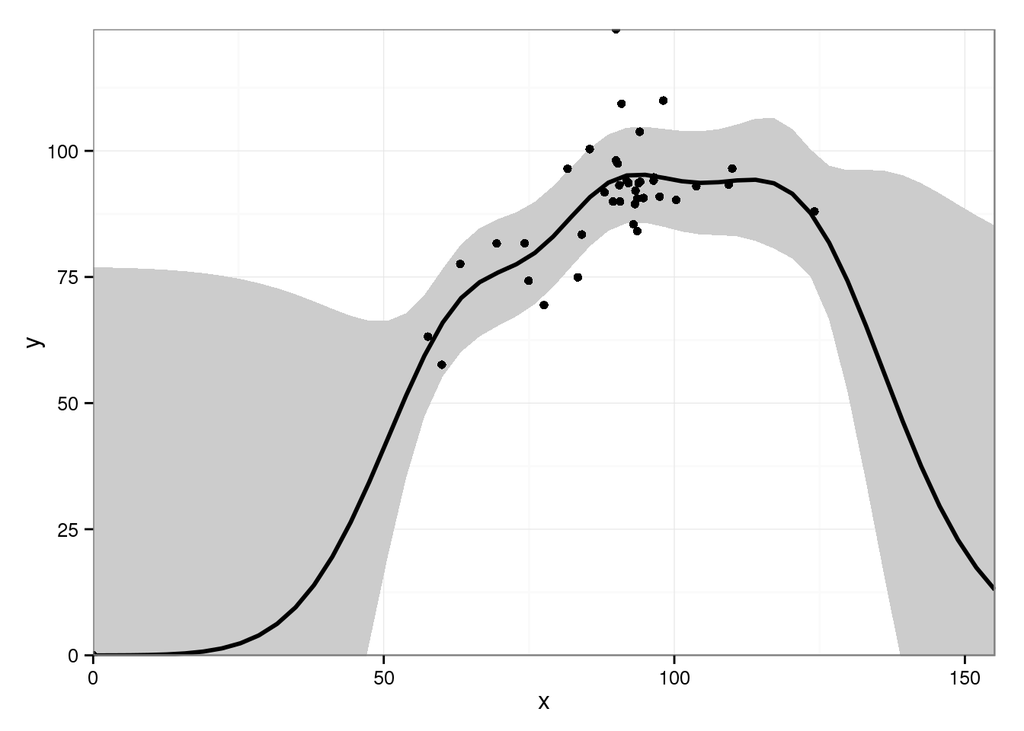

```r
  E <- Cpred$getE()
  C <- Cpred$getC()

obs <- data.frame(x = xObs, y = yObs)
pred <- data.frame(x = xPred, y = E, ymin = E - sqrt(diag(C)), ymax = E + sqrt(diag(C)))
ggplot2::ggplot(pred) +
  geom_ribbon(aes(x = x,y = y, ymin = ymin, ymax = ymax), fill = "grey80") +
  geom_line(aes(x = x, y = y), size=1) +
  geom_point(data = obs, aes(x,y)) +
  coord_cartesian(xlim = range(c(xObs, xPred)), ylim = range(c(yObs,E))) +
  theme_bw()
```

Posteriors

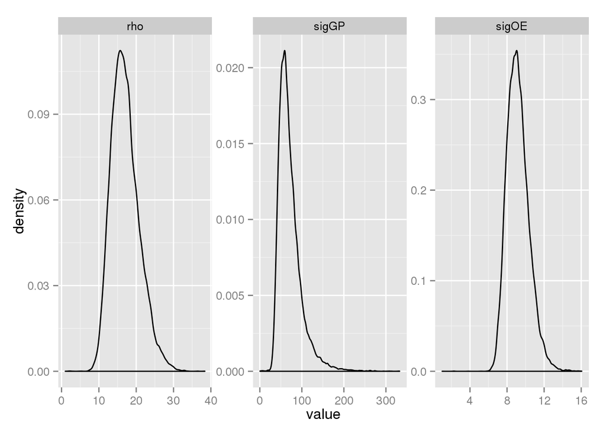

```r
samples <- as.data.frame(as.matrix(Cmcmc$mvSamples))
df <- tidyr::gather(samples)
ggplot(df) +
  geom_density(aes(value)) +
  facet_wrap(~key, scale='free')
```

### Longer length scale

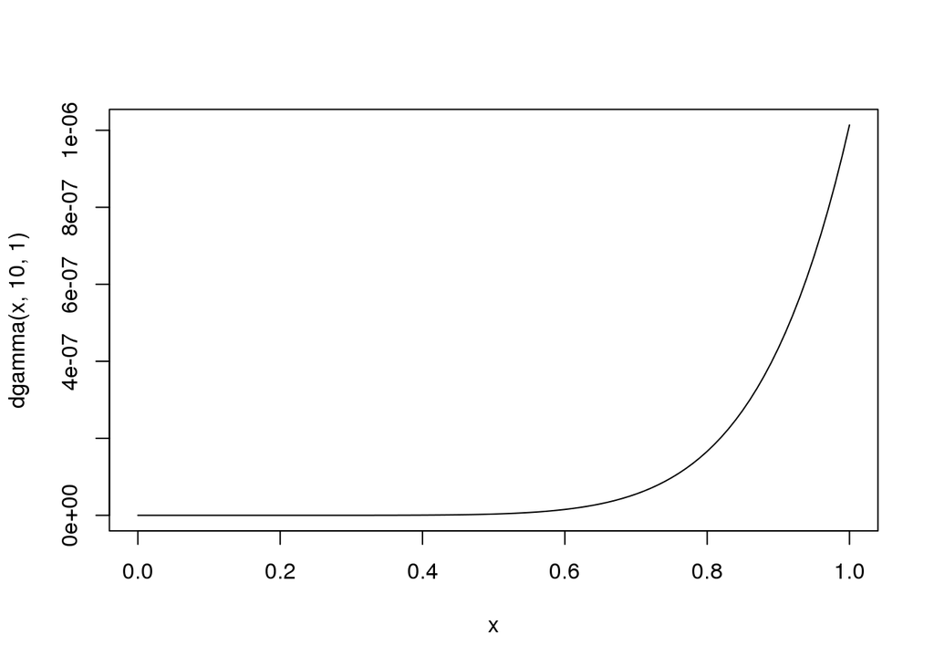

```r
# having this work with output from `nimbleCode` might be more natural than `expression`
priors <- expression({
  rho ~ dgamma(10, 1)
  sigGP ~ dunif(0, 1e5)
  sigOE ~ dunif(0, 1e5)
})
curve(dgamma(x, 10, 1))
```

```r
fit <- gp_setup(xObs[2:Tobs], yObs[2:Tobs], xPred)
```

```
## [1] RW_block sampler: rho, sigGP, sigOE,  adaptive: TRUE,  adaptScaleOnly: FALSE,  adaptInterval: 200,  scale: 1,  propCov: identity
```

```r
Cmcmc <- fit$Cmcmc
Cpred <- fit$Cpred
Cmodel <- fit$Cmodel
```

```r
system.time(Cmcmc$run(100000))
```

```
##    user  system elapsed
##  16.996   0.048  17.032
```

```r
  samples <- as.matrix(Cmcmc$mvSamples)
  ## basic sanity check
  testthat::expect_identical(Cmodel$getNodeNames(topOnly = TRUE), colnames(samples))
```

predict from GP model using posterior MCMC samples

```r
system.time(Cpred$run(samples))
```

```
##    user  system elapsed
##  22.412   0.000  22.395
```

extract predictions: E and C

```r
  E2 <- Cpred$getE()
  C2 <- Cpred$getC()
```

sanity check: these should be different

```r
identical(E, E2)
```

```
## [1] FALSE
```

```r
identical(C, C2)
```

```
## [1] FALSE
```

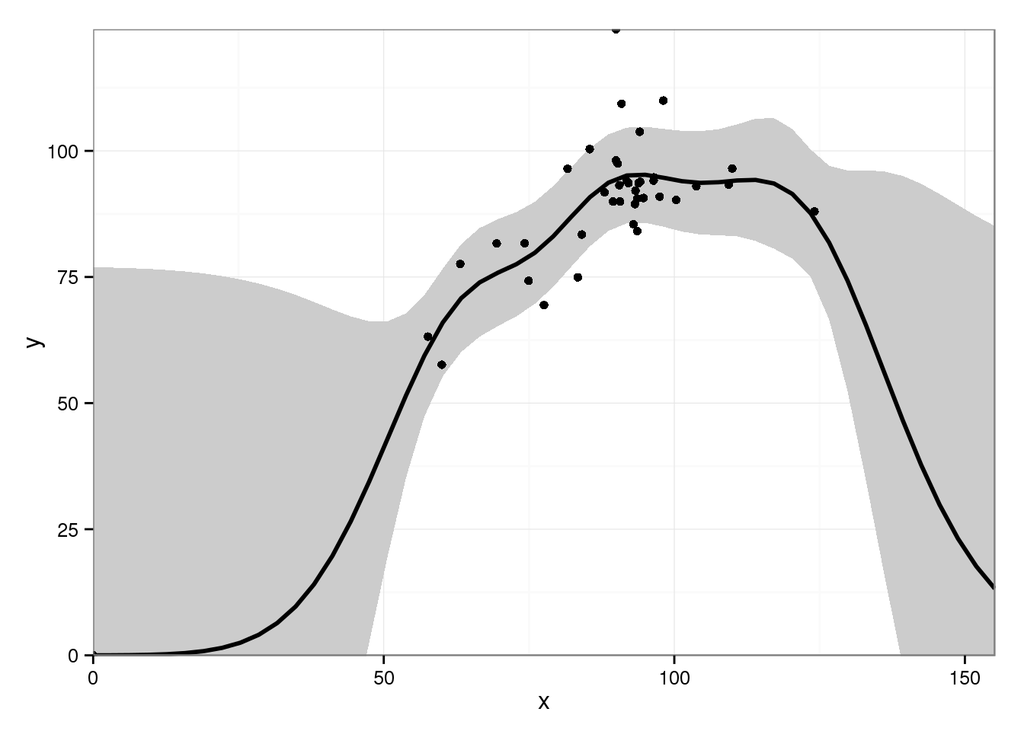

```r
obs <- data.frame(x = xObs, y = yObs)
pred <- data.frame(x = xPred, y = E2, ymin = E2 - sqrt(diag(C2)), ymax = E + sqrt(diag(C2)))
ggplot2::ggplot(pred) +
  geom_ribbon(aes(x = x,y = y, ymin = ymin, ymax = ymax), fill = "grey80") +
  geom_line(aes(x = x, y = y), size=1) +
  geom_point(data = obs, aes(x,y)) +
  coord_cartesian(xlim = range(c(xObs, xPred)), ylim = range(c(yObs,E))) +
  theme_bw()
```

Posteriors

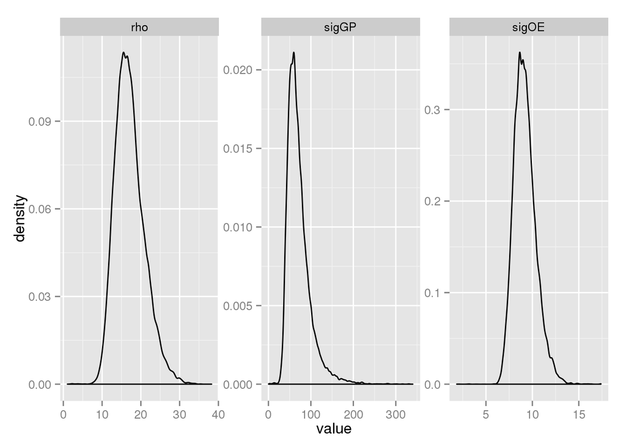

```r
samples <- as.data.frame(as.matrix(Cmcmc$mvSamples))
df <- tidyr::gather(samples)
ggplot(df) +
  geom_density(aes(value)) +
  facet_wrap(~key, scale='free')
```

29 Jul 2015

prev

[history](https://github.com/cboettig/2015/commits/master/_posts/2015-07-29-nimble-gp-comparing-priors.html)

Posted in

tags:

SHA Hash: